# 作业1: 数据探索性分析与数据预处理

322010840 刘聪聪

## 1. 问题描述

自行选择2个数据集进行探索性分析与预处理。

所选数据集：

oakland-crime-statistics-2011-to-2016

## 2.数据集

2011-2016年的奥克兰犯罪统计数据

从2011-2016年，一共6个csv文件

records-for-2011.csv

records-for-2012.csv

records-for-2013.csv

records-for-2014.csv

records-for-2015.csv

records-for-2016.csv

导入库

```python
import matplotlib
import numpy as np
import pandas as pd
%matplotlib inline
```

载入数据

```python
path_list = []
for i in range(2011,2017):
    path_list.append("data/oakland-crime-statistics-2011-to-2016/records-for-%s.csv"%(str(i)))
data = []
for path in path_list:
    data.append(pd.read_csv(path ))
```

数据的属性

```python
print(data[0].dtypes)
```

```
Agency                        object
Create Time                   object
Location                      object
Area Id                      float64
Beat                          object
Priority                     float64
Incident Type Id              object
Incident Type Description     object
Event Number                  object
Closed Time                   object
dtype: object
```

- Agency 机构
- Create Time 建立时间
- Location 位置
- Area Id 区域ID
- Beat
- Priority 优先级
- Incident Type Id 事件类型ID
- Incident Type Description 事件类型描述
- Event Number 事件号
- Closed Time 结束时间

## 3. 数据分析

### 3.1 数据可视化与摘要

### - 可视化分析与摘要 records-for-2011.csv

```python
tmp_data = data[0]
```

统计Agency属性每个可能聚会的频数:

```python
print(tmp_data.Agency.value_counts(dropna = False))
```

```
OP     180015
NaN         1
Name: Agency, dtype: int64
```

Agency属性数据分布：

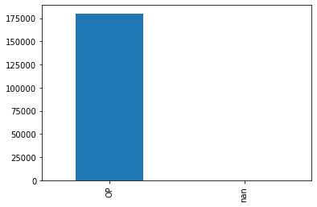

```python
tmp_data.Agency.value_counts(dropna = False).plot(kind='bar')
```

统计Area Id属性每个可能聚会的频数:

```python
attri = "Area Id"
print(tmp_data[attri].value_counts(dropna = False))
```

```
1.0    79152
2.0    67261
3.0    32699
NaN      904
Name: Area Id, dtype: int64
```

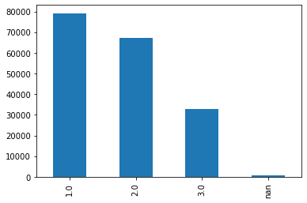

```python
tmp_data[attri].value_counts(dropna = False).plot(kind='bar')
```

统计Beat属性每个可能聚会的频数:

```python
attri = "Beat"
print(tmp_data[attri].value_counts(dropna = False))
```

```
04X     7410
08X     6885
26Y     5478
30Y     5295
06X     5119
23X     5051
30X     4956
19X     4955
34X     4673
29X     4483
20X     4287
27Y     4159
07X     4134
31Y     4082
25X     4022
35X     3880
33X     3849
03X     3819
32X     3711
27X     3703
09X     3630
21Y     3435
32Y     3125
22X     3061
26X     2978
02Y     2970
10X     2967
14X     2733
03Y     2726
22Y     2664
12Y     2651
05X     2633
02X     2614
31X     2603
21X     2593
17Y     2582
24Y     2575
13Z     2546
15X     2509
24X     2459
12X     2422
10Y     2383
01X     2210
28X     2191
17X     2133
11X     2087
13Y     2017
35Y     1956
31Z     1870
18Y     1778
16Y     1561
14Y     1492
25Y     1482
13X     1122
18X     1063
16X      994
05Y      710
NaN      520
PDT2      20
Name: Beat, dtype: int64
```

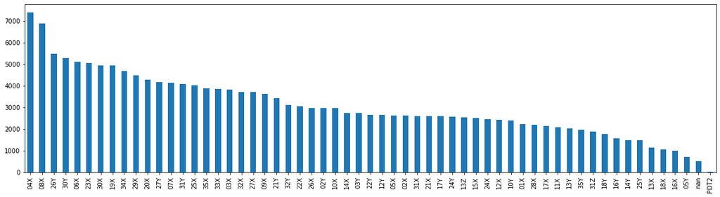

```python
tmp_data[attri].value_counts(dropna = False).plot(kind='bar',figsize=(20,5))
```

统计Priority属性每个可能聚会的频数:

```python
attri = "Priority"
print(tmp_data[attri].value_counts(dropna = False))
```

```
2.0    143314
1.0     36699
0.0         2
NaN         1
Name: Priority, dtype: int64
```

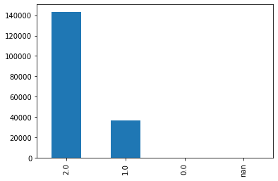

```python
tmp_data[attri].value_counts(dropna = False).plot(kind='bar')
```

统计Incident Type Id属性每个可能聚会的频数:

```python
attri = "Incident Type Id"
print(tmp_data[attri].value_counts(dropna = False))
```

```
933R      17348
911H      12817
SECCK     11393
415       10752
10851      7180
          ...
YELALT        1
140           1
593           1
12020         1
NaN           1
Name: Incident Type Id, Length: 264, dtype: int64
```

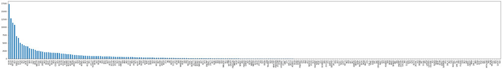

```python
tmp_data[attri].value_counts(dropna = False).plot(kind='bar',figsize=(50,6))
```

```python
attri = "Incident Type Description"
print(tmp_data[attri].value_counts(dropna = False))
```

```
ALARM-RINGER            17348
911 HANG-UP             12817
SECURITY CHECK          11393
STOLEN VEHICLE           7180
415 UNKNOWN              6624
                        ...
YELLOW ALERT AT THE         1
LOCKOUT                     1
ASSAULT ON A POLICE         1
PLAYING BALL IN STRE        1
NaN                         1
Name: Incident Type Description, Length: 266, dtype: int64
```

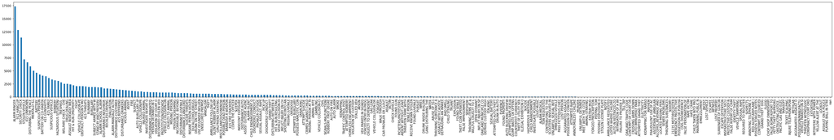

```python
tmp_data[attri].value_counts(dropna = False).plot(kind='bar',figsize=(50,6))
```

### - 可视化分析与摘要 其它年份的csv文件

```python
def analysis():
    #matplotlib.pyplot.subplot(2,2,1)
    attri = "Agency"
    print(tmp_data[attri].value_counts(dropna = False))
    #tmp_data[attri].value_counts(dropna = False).plot(kind='bar')
    print(" ")

    attri = "Area Id"
    print(tmp_data[attri].value_counts(dropna = False))
    #matplotlib.pyplot.subplot(2,2,2)
    #tmp_data[attri].value_counts(dropna = False).plot(kind='bar')
    print(" ")

    attri = "Beat"
    print(tmp_data[attri].value_counts(dropna = False))
    #tmp_data[attri].value_counts(dropna = False).plot(kind='bar',figuresize=(20,5))
    print(" ")

    attri = "Priority"
    print(tmp_data[attri].value_counts(dropna = False))
    #tmp_data[attri].value_counts(dropna = False).plot(kind='bar')
    print(" ")

    attri = "Incident Type Id"
    print(tmp_data[attri].value_counts(dropna = False))
    #tmp_data[attri].value_counts(dropna = False).plot(kind='bar',figsize=(50,6))
    print(" ")

    attri = "Incident Type Description"
    print(tmp_data[attri].value_counts(dropna = False))
    #tmp_data[attri].value_counts(dropna = False).plot(kind='bar',figsize=(50,6))
    print(" ")

#     print(tmp_data.isnull().sum(axis=0))

for i in range(1,5):
    print("### records-for-201%d.csv"%(i+1))
    print("")
    tmp_data = data[i]
    analysis()
```

```
### records-for-2012.csv

OP     187430
NaN         1
Name: Agency, dtype: int64

1.0    101053
2.0     84963
NaN      1415
Name: Area Id, dtype: int64

04X     8088
08X     6691
30Y     5529
26Y     5374
23X     5301
19X     5158
30X     4988
34X     4965
20X     4682
06X     4676
29X     4606
25X     4396
03X     4380
35X     4291
07X     4235
31Y     3975
09X     3845
32X     3836
21Y     3822
27Y     3701
33X     3697
27X     3685
12Y     3344
32Y     3328
22X     3131
14X     3070
02Y     3043
03Y     3009
26X     2982
```

[output cut: 360 more lines]

```
243B         1
Name: Incident Type Id, Length: 259, dtype: int64

ALARM-RINGER            18181
SECURITY CHECK          14809
STOLEN VEHICLE           8899
911 HANG-UP              8529
MENTALLY ILL             8465
                        ...
TICKET SCALPING             1
DROWNING                    1
POSSESS FORGED NOTES        1
PHONE RPT                   1
RED ALERT-AIRPLANE I        1
Name: Incident Type Description, Length: 262, dtype: int64
```

## 3.2 处理数据缺失

1. 将缺失部分剔除
2. 用最高频率值来填补缺失值
3. 通过属性的相关关系来填补缺失值
4. 通过数据对象之间的相似性来填补缺失值

### - 缺失数据处理 records-for-2011.csv

属性缺失值统计

```python
tmp_data = data[0]
print(tmp_data.isnull().sum(axis=0))
```

```
Agency                         1
Create Time                    1
Location                       0
Area Id                      904
Beat                         520
Priority                       1
Incident Type Id               1
Incident Type Description      1
Event Number                   1
Closed Time                    7
dtype: int64
```

#### Area Id 属性缺失处理

缺失的原因可能是人为失误

- 将缺失部分剔除

```python
attri = "Area Id"
d = tmp_data.dropna(subset=[attri])
d
```

|  | Agency | Create Time | Location | Area Id | Beat | Priority | Incident Type Id | Incident Type Description | Event Number | Closed Time |
| --- | --- | --- | --- | --- | --- | --- | --- | --- | --- | --- |
| 0 | OP | 2011-01-01T00:00:00.000 | ST&SAN PABLO AV | 1.0 | 06X | 1.0 | PDOA | POSSIBLE DEAD PERSON | LOP110101000001 | 2011-01-01T00:28:17.000 |
| 1 | OP | 2011-01-01T00:01:11.000 | ST&HANNAH ST | 1.0 | 07X | 1.0 | 415GS | 415 GUNSHOTS | LOP110101000002 | 2011-01-01T01:12:56.000 |
| 2 | OP | 2011-01-01T00:01:25.000 | ST&MARKET ST | 1.0 | 10Y | 2.0 | 415GS | 415 GUNSHOTS | LOP110101000003 | 2011-01-01T00:07:20.000 |
| 3 | OP | 2011-01-01T00:01:35.000 | PRENTISS ST | 2.0 | 21Y | 2.0 | 415GS | 415 GUNSHOTS | LOP110101000005 | 2011-01-01T00:02:28.000 |
| 4 | OP | 2011-01-01T00:02:10.000 | AV&FOOTHILL BLVD | 2.0 | 20X | 1.0 | 415GS | 415 GUNSHOTS | LOP110101000004 | 2011-01-01T00:50:04.000 |
| ... | ... | ... | ... | ... | ... | ... | ... | ... | ... | ... |
| 180010 | OP | 2011-12-31T23:51:14.000 | WB REDWOOD RD&REDWOOD RD | 1.0 | 22Y | 2.0 | SECCK | SECURITY CHECK | LOP111231001011 | 2012-01-01T00:44:22.000 |
| 180011 | OP | 2011-12-31T23:52:15.000 | WB 26TH AV | 2.0 | 21X | 2.0 | 415GS | 415 GUNSHOTS | LOP111231001014 | 2012-01-01T01:40:10.000 |
| 180012 | OP | 2011-12-31T23:53:59.000 | WERNER 40TH STREET WY | 1.0 | 09X | 1.0 | PDOA | POSSIBLE DEAD PERSON | LOP111231001015 | 2012-01-01T02:30:22.000 |
| 180013 | OP | 2011-12-31T23:55:52.000 | WOOD AV&KEMPTON AV | 1.0 | 08X | 1.0 | 918 | PERSON SCREAMING | LOP111231001016 | 2012-01-01T00:25:03.000 |
| 180014 | OP | 2011-12-31T23:58:08.000 | WOODSON B ST | 2.0 | 33X | 2.0 | 415GS | 415 GUNSHOTS | LOP111231001017 | 2012-01-01T02:59:48.000 |

179112 rows × 10 columns

可视化对比

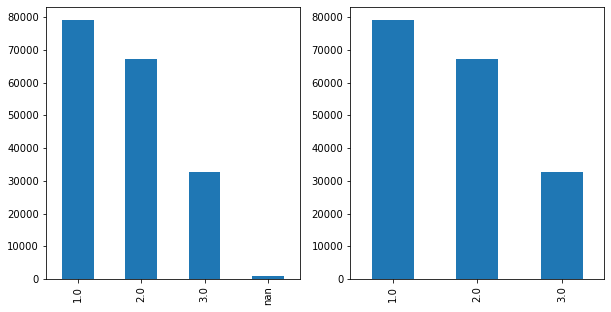

```python
matplotlib.pyplot.subplot(1,2,1)
tmp_data[attri].value_counts(dropna = False).plot(kind='bar',figsize=(10,5))
matplotlib.pyplot.subplot(1,2,2)
d[attri].value_counts(dropna = False).plot(kind='bar')
```

- 用最高频率值来填补缺失值

```python
mode = tmp_data[attri].mode()
#int(mode)
f = tmp_data[attri].fillna(int(mode))
print(f)
f.value_counts(dropna = False)
```

```
0         1.0
1         1.0
2         1.0
3         2.0
4         2.0
         ...
180011    2.0
180012    1.0
180013    1.0
180014    2.0
180015    1.0
Name: Area Id, Length: 180016, dtype: float64
```

```
1.0    80056
2.0    67261
3.0    32699
Name: Area Id, dtype: int64
```

可视化对比

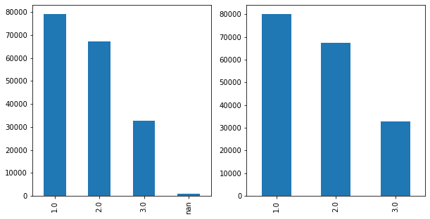

```python
matplotlib.pyplot.subplot(1,2,1)
tmp_data[attri].value_counts(dropna = False).plot(kind='bar',figsize=(10,5))
matplotlib.pyplot.subplot(1,2,2)
f.value_counts(dropna = False).plot(kind='bar',figsize=(10,5))
```

#### Beat属性缺失处理

可能是人为失误导致缺失值

- 将缺失部分剔除

```python
attri = "Beat"
d = tmp_data.dropna(subset=[attri])
d
```

|  | Agency | Create Time | Location | Area Id | Beat | Priority | Incident Type Id | Incident Type Description | Event Number | Closed Time |
| --- | --- | --- | --- | --- | --- | --- | --- | --- | --- | --- |
| 0 | OP | 2011-01-01T00:00:00.000 | ST&SAN PABLO AV | 1.0 | 06X | 1.0 | PDOA | POSSIBLE DEAD PERSON | LOP110101000001 | 2011-01-01T00:28:17.000 |
| 1 | OP | 2011-01-01T00:01:11.000 | ST&HANNAH ST | 1.0 | 07X | 1.0 | 415GS | 415 GUNSHOTS | LOP110101000002 | 2011-01-01T01:12:56.000 |
| 2 | OP | 2011-01-01T00:01:25.000 | ST&MARKET ST | 1.0 | 10Y | 2.0 | 415GS | 415 GUNSHOTS | LOP110101000003 | 2011-01-01T00:07:20.000 |
| 3 | OP | 2011-01-01T00:01:35.000 | PRENTISS ST | 2.0 | 21Y | 2.0 | 415GS | 415 GUNSHOTS | LOP110101000005 | 2011-01-01T00:02:28.000 |
| 4 | OP | 2011-01-01T00:02:10.000 | AV&FOOTHILL BLVD | 2.0 | 20X | 1.0 | 415GS | 415 GUNSHOTS | LOP110101000004 | 2011-01-01T00:50:04.000 |
| ... | ... | ... | ... | ... | ... | ... | ... | ... | ... | ... |
| 180010 | OP | 2011-12-31T23:51:14.000 | WB REDWOOD RD&REDWOOD RD | 1.0 | 22Y | 2.0 | SECCK | SECURITY CHECK | LOP111231001011 | 2012-01-01T00:44:22.000 |
| 180011 | OP | 2011-12-31T23:52:15.000 | WB 26TH AV | 2.0 | 21X | 2.0 | 415GS | 415 GUNSHOTS | LOP111231001014 | 2012-01-01T01:40:10.000 |
| 180012 | OP | 2011-12-31T23:53:59.000 | WERNER 40TH STREET WY | 1.0 | 09X | 1.0 | PDOA | POSSIBLE DEAD PERSON | LOP111231001015 | 2012-01-01T02:30:22.000 |
| 180013 | OP | 2011-12-31T23:55:52.000 | WOOD AV&KEMPTON AV | 1.0 | 08X | 1.0 | 918 | PERSON SCREAMING | LOP111231001016 | 2012-01-01T00:25:03.000 |
| 180014 | OP | 2011-12-31T23:58:08.000 | WOODSON B ST | 2.0 | 33X | 2.0 | 415GS | 415 GUNSHOTS | LOP111231001017 | 2012-01-01T02:59:48.000 |

179496 rows × 10 columns

可视化对比

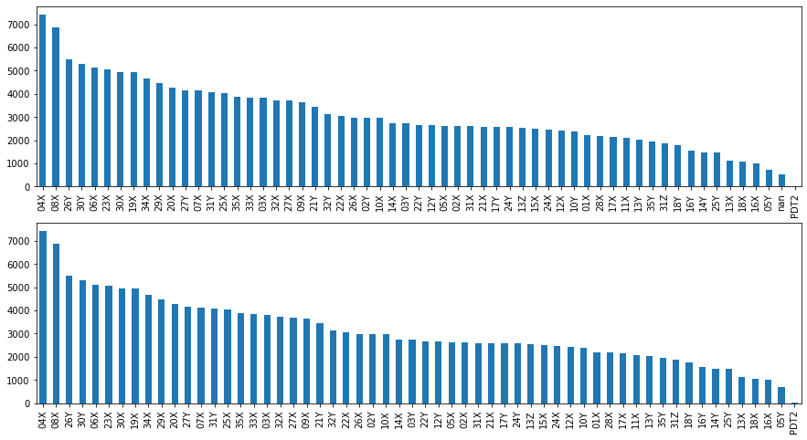

```python
matplotlib.pyplot.subplot(2,1,1)
tmp_data[attri].value_counts(dropna = False).plot(kind='bar',figsize=(15,8))
matplotlib.pyplot.subplot(2,1,2)
d[attri].value_counts(dropna = False).plot(kind='bar',figsize=(15,8))
```

### 其它csv文件的缺失值处理

```python
def nanHander():
    #剔除包含缺失值的行
    d = tmp_data.dropna(how='any')
    #输出
    print(d)
```

- records-for-2012.csv

```python
tmp_data = data[1]
nanHander()
```

```
       Agency              Create Time  Area Id Beat  Priority  \
187256     OP  2012-01-11T13:17:59.000      2.0  28X       2.0
187257     OP  2012-01-01T07:27:25.000      2.0  23X       1.0
187258     OP  2012-01-05T07:21:49.000      1.0  12X       2.0
187260     OP  2012-01-14T18:34:28.000      2.0  33X       2.0
187261     OP  2012-02-15T05:20:20.000      1.0  06X       2.0
...       ...                      ...      ...  ...       ...
187421     OP  2012-12-22T15:08:15.000      1.0  12Y       2.0
187424     OP  2012-11-26T16:55:33.000      2.0  30X       2.0
187426     OP  2012-11-26T22:54:15.000      1.0  25X       1.0
187427     OP  2012-11-29T04:04:54.000      1.0  08X       2.0
187429     OP  2012-11-29T04:41:24.000      2.0  31X       2.0

       Incident Type Id Incident Type Description     Event Number  \
187256              901      VEHICLE COLLISION/PR  LOP120111000450
```

[output cut: 38 more lines]

- records-for-2013.csv

```python
tmp_data = data[2]
nanHander()
```

```
       Agency              Create Time                       Location   \
0          OP  2013-01-01T00:00:00.000                        D ST
1          OP  2013-01-01T00:00:05.000                   ARTHUR ST
2          OP  2013-01-01T00:00:50.000                   BRIDGE AV
3          OP  2013-01-01T00:02:16.000             AV&BROOKDALE AV
4          OP  2013-01-01T00:02:47.000            AV&SAN LEANDRO ST
...       ...                      ...                             ...
188046     OP  2013-12-31T23:51:08.000            WHITNEY E 16TH ST
188047     OP  2013-12-31T23:51:59.000  WHITTLE BLVD&HARRINGTON AV
188048     OP  2013-12-31T23:52:03.000   WHITTLE AV&MACARTHUR BLVD
188049     OP  2013-12-31T23:54:20.000       WOOLSLEY, RD&MAKIN RD
188050     OP  2013-12-31T23:58:32.000           WYMAN AV&OLIVE ST

        Area Id Beat  Priority Incident Type Id Incident Type Description  \
0           2.0  33X       1.0            415GS              415 GUNSHOTS
```

[output cut: 25 more lines]

- records-for-2014.csv

```python
tmp_data = data[3]
d = tmp_data.dropna(subset = ['Agency','Beat','Priority','Event Number','Closed Time','Area Id'])
print(d)
```

```
     Agency              Create Time  Area Id Beat  Priority Incident Type Id  \
0        OP  2014-01-01T00:00:00.000      1.0  02X         2            415GS
1        OP  2014-01-01T00:00:00.000      2.0  26Y         2            415GS
2        OP  2014-01-01T00:00:00.000      2.0  30Y         2            415GS
3        OP  2014-01-01T00:00:00.000      2.0  30Y         2            415GS
4        OP  2014-01-01T00:01:04.000      2.0  35X         2            CODE7
...     ...                      ...      ...  ...       ...              ...
9821     OP  2014-01-21T04:22:39.000      1.0  04X         2             EVAL
9822     OP  2014-01-21T04:23:14.000      4.0  27X         2             933R
9823     OP  2014-01-21T04:42:14.000      2.0  08X         2              912
9824     OP  2014-01-21T04:56:33.000      1.0  06X         2              314
9825     OP  2014-01-21T05:16:22.000      2.0  34X         2            SECCK

     Incident Type Description     Event Number              Closed Time  \
0                 415 GUNSHOTS  LOP140101000001  2014-01-01T03:22:08.000
```

[output cut: 25 more lines]

- records-for-2015.csv

```python
tmp_data = data[4]
nanHander()
```

```
       Agency              Create Time                      Location Area Id  \
0          OP  2015-01-01T00:01:59.000              S ELMHURST AV         P3
1          OP  2015-01-01T00:02:02.000                   AV&D ST          P3
2          OP  2015-01-01T00:02:06.000               BANCROFT AV          P3
3          OP  2015-01-01T00:03:16.000            MACARTHUR BLVD          P3
4          OP  2015-01-01T00:03:45.000             ST&ADELINE ST          P1
...       ...                      ...                           ...     ...
192576     OP  2015-12-31T23:56:55.000  WHITNEY ST&MOUNTAIN BLVD          P3
192577     OP  2015-12-31T23:57:26.000        WHITTLE CASWELL AV          P3
192578     OP  2015-12-31T23:57:43.000         WILDWOOD E 12TH ST         P3
192579     OP  2015-12-31T23:58:11.000     YERB&HOL AV&HUDSON ST          P1
192580     OP  2015-12-31T23:59:37.000      YERBA ST&SHATTUCK AV          P1

       Beat  Priority Incident Type Id Incident Type Description  \
0       31Y         2              415      DISTURBING THE PEACE
```

[output cut: 25 more lines]

- records-for-2016.csv

```python
tmp_data = data[5]
nanHander()
```

```
       Agency              Create Time                 Location Area Id Beat  \
0          OP  2016-01-01T00:00:57.000         ST&MARKET ST          P1  05X
1          OP  2016-01-01T00:01:25.000       AV&HAMILTON ST          P3  26Y
2          OP  2016-01-01T00:01:43.000       ST&CHESTNUT ST          P1  02X
3          OP  2016-01-01T00:01:48.000           WALLACE ST          P2  18Y
4          OP  2016-01-01T00:02:05.000              90TH AV          P3  34X
...       ...                      ...                      ...     ...  ...
110822     OP  2016-07-31T23:43:51.000   WENDY'S ST&PINE ST          P1  02Y
110823     OP  2016-07-31T23:45:50.000  WHITMORE ST&WOOD ST          P1  02Y
110824     OP  2016-07-31T23:50:54.000      WHITTLE 69TH AV          P3  26Y
110825     OP  2016-07-31T23:56:29.000    WHITTLE LOOMIS CT          P2  19X
110826     OP  2016-07-31T23:57:31.000       WYMAN LACEY AV          P3  29X

        Priority Incident Type Id Incident Type Description     Event Number  \
0            2.0            415GS              415 GUNSHOTS  LOP160101000003
```

[output cut: 25 more lines]